# Problem Set 1: R Language

Heatherlee Leary

2023-02-08

## **Question 1**

#### Install the ISwR R package.

#### Write the built-in dataset thuesen to a tab-separated text file.

#### View it with a text editor.

#### Change the NA to . (period)

#### Read the changed file back into R.

```r
# Install and load the ISwR R Package.
install.packages("ISwR", repos = "http://cran.us.r-project.org")
library("ISwR")
# Write the built-in dataset thuesen to a tab-separated text file.
data(package = "ISwR") # Run to see the data sets within the ISwR package.
thuesen_df <- as.data.frame(thuesen)  # Read the dataset thuesen in the package ISwR
head(thuesen_df) # View the first few rows of the dataset thuesen
```

```
##   blood.glucose short.velocity
## 1          15.3           1.76
## 2          10.8           1.34
## 3           8.1           1.27
## 4          19.5           1.47
## 5           7.2           1.27
## 6           5.3           1.49
```

```r
write.table(thuesen_df, "C:\\Users\\hlear\\Desktop\\statsandviz\\R01_r_language\\data\\thuesen_tab.txt", row.names=FALSE) # Don't export row names.


# I viewed thuesen_tab in Notepad and changed "NA" to "." (period)


# Read the changed file back into R.
thuesen_tab <- read.table(file = "C:\\Users\\hlear\\Desktop\\statsandviz\\R01_r_language\\data\\thuesen_tab.txt", header = TRUE) # Has a header
head(thuesen_tab)
```

```
##   blood.glucose short.velocity
## 1          15.3           1.76
## 2          10.8           1.34
## 3           8.1           1.27
## 4          19.5           1.47
## 5           7.2           1.27
## 6           5.3           1.49
```

## **Question 2**

#### The exponential growth of a population is described by this mathematical function: Nt=Ni * e^rt

#### where Nt is the population size at time t, Ni is the initial population size, and r is the rate of growth or reproductive rate.

#### Write an exponential growth function in R that also generates a plot with time on the x axis and Nt on the y axis. Using that function, create plots for 20 days assuming an initial population size of 10 individuals under three growth rate scenarios (0.5, 0.8, -0.1).

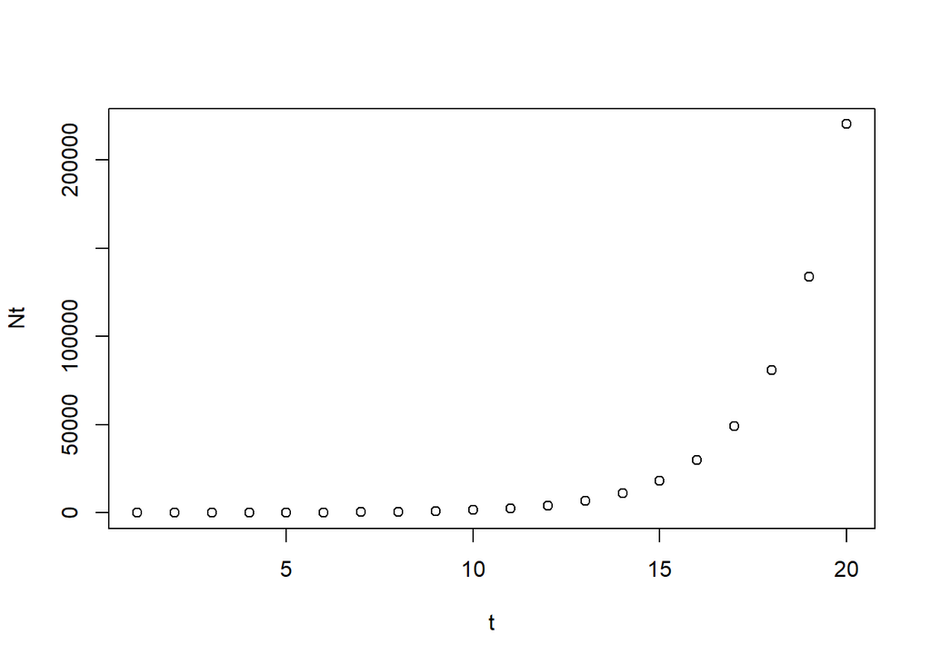

```r
# Write an exponential growth function.
Ni <- 10
t <- c(1:20)


Nt <- function(r){
  Nt <- Ni * exp(r*t)
  plot(t, Nt)
}


# Test under three growth rate scenarios.
Nt(0.5)
```

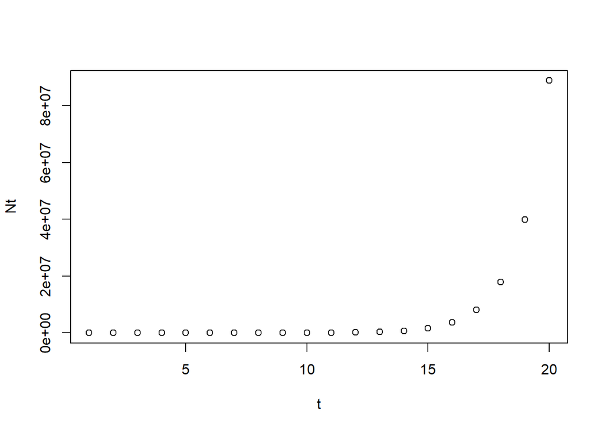

```r
Nt(0.8)
```

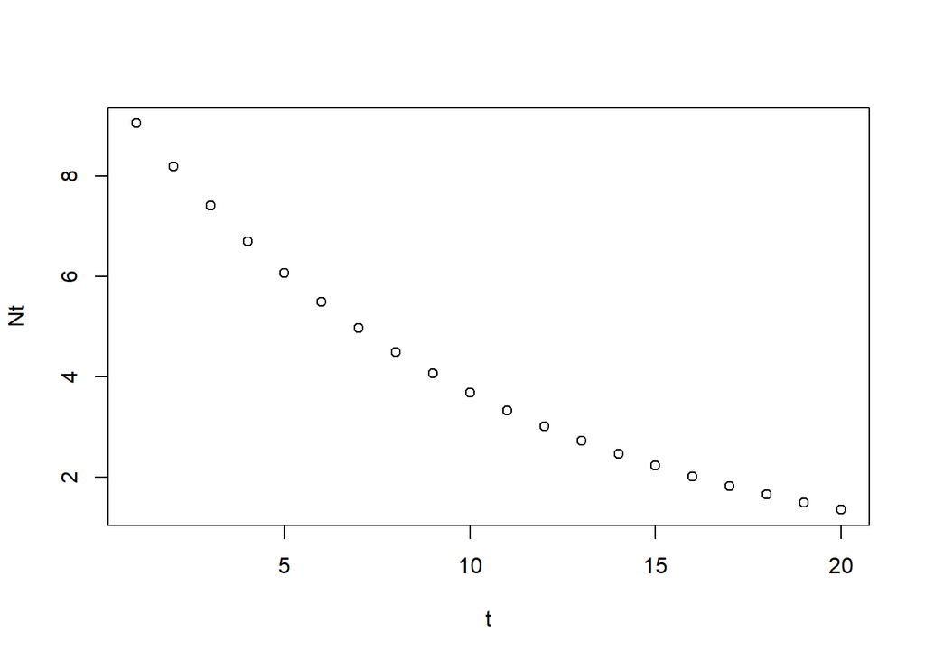

```r
Nt(-0.1)
```

## **Question 3**

#### Under highly favorable conditions, populations grow exponentially.However resources will eventually limit population growth and exponential growth cannot continue indefinitely. This phenomenon is described by the logistic growth function: Nt=(K*Ni)/(Ni+(K-Ni)e^(-rt))

#### where K is the carrying capacity.

#### Write a logistic growth function in R that also generates a plot with time on the x axis and Nt on the y axis. Using that function create plots for 20 days assuming an initial population size of 10 individuals and a carrying capacity of 1,000 individuals under three growth rate scenarios (0.5, 0.8, 0.4).

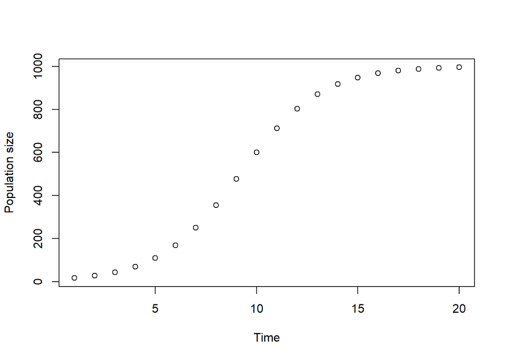

```r
# Logistic growth function.
Ni <- 10
t <- c(1:20)
K <- 1000

log_growth <- function (r) {
  Nt <- K*Ni/(Ni+(K-Ni) * exp(1)^(-r*t))
  plot(t, Nt, xlab="Time", ylab="Population size")
       }

# Test under three growth rate scenarios
log_growth(0.5)
```

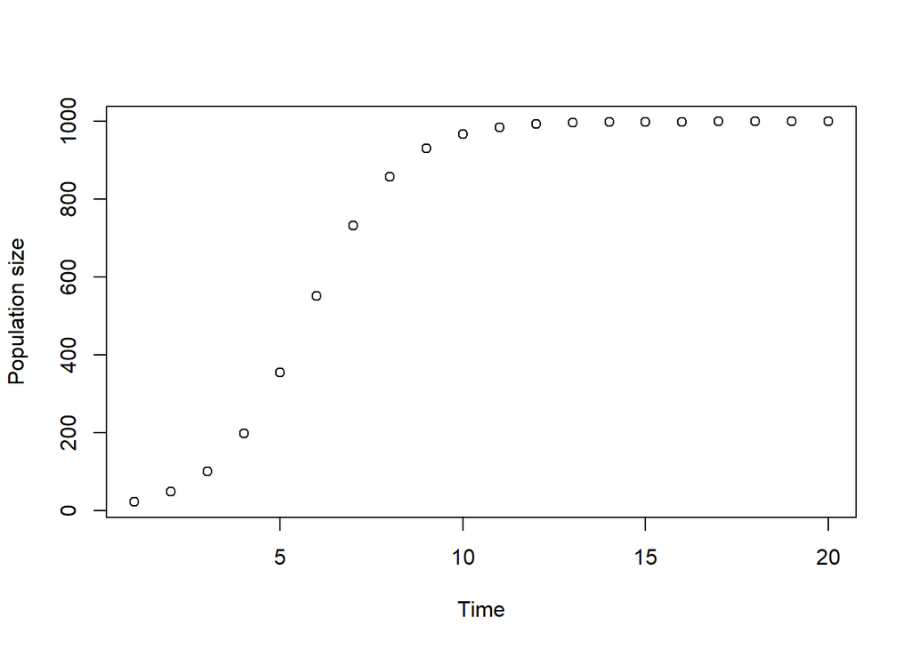

```r
log_growth(0.8)
```

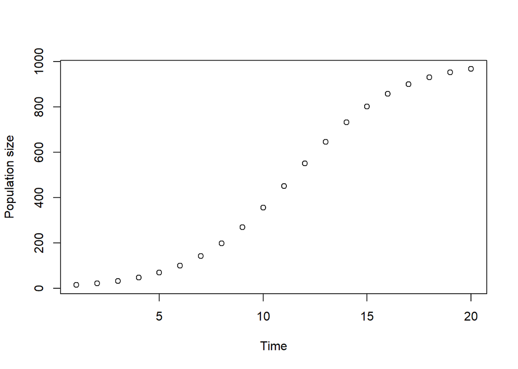

```r
log_growth(0.4)
```

## **Question 4**

#### Write a function (sum_n) that for any given value, say n, computes the sum of the integers from 1 to n (inclusive). Use the function to determine the sum of integers from 1 to 5,000.

```r
# Write a function that computes the sum of integers from 1 to n (inclusive).
sum_n <- function(n){sum(1:n)}


# Quick test with n = 5.
1+2+3+4+5 # Run this to see what the sum of integers from 1 to 5 equals.
```

```
## [1] 15
```

```r
sum_n(5) # Now test the function with n = 5.
```

```
## [1] 15
```

```r
# Use the function to determine the sum of integers from 1 to 5,000.
sum_n(5000)
```

```
## [1] 12502500
```

## **Question 5**

#### Write a function (sqrt_round) that takes a number x as input, takes the square root, rounds it to the nearest whole number and then returns the result.

```r
sqrt_round <- function(x) {
  result <- round(sqrt(x))
  return(result)
}


# Test
sqrt(17)
```

```
## [1] 4.123106
```

```r
sqrt_round(17)
```

```
## [1] 4
```

## **Question 6**

#### Install the R package ‘nycflights13’, and load the ‘weather’ data.

#### a) Explore the columns names and the top part of the dataset to get a sense of the data

#### b) Make a subset of the data from just the first month (1) and then save that subset as ‘weather1’

#### c) Using ggplot2, make a beautiful histogram of the variable ‘temp’

#### d) Using ggplot2, make a beautiful line plot of ‘temp’ as a function of ‘time_hour’

#### e) Using ggplot2, make a beautiful boxplot of ‘temp’ as a function of ‘origin’

```r
# Install the R package ‘nycflights13’, and load the ‘weather’ data.
install.packages("nycflights13", repos = "http://cran.us.r-project.org")
data(package = "nycflights13") # Run to see data sets within the nycflights13 package. Weather is in there.
library(nycflights13)
# a) Explore the column names and top part of the dataset to get a sense of the data.
colnames(weather) # View column names only.
```

```
##  [1] "origin"     "year"       "month"      "day"        "hour"
##  [6] "temp"       "dewp"       "humid"      "wind_dir"   "wind_speed"
## [11] "wind_gust"  "precip"     "pressure"   "visib"      "time_hour"
```

```r
head(weather) # View top part of the data.
```

```
## # A tibble: 6 × 15
##   origin  year month   day  hour  temp  dewp humid wind_dir wind_speed wind_gust
##   <chr>  <int> <int> <int> <int> <dbl> <dbl> <dbl>    <dbl>      <dbl>     <dbl>
## 1 EWR     2013     1     1     1  39.0  26.1  59.4      270      10.4         NA
## 2 EWR     2013     1     1     2  39.0  27.0  61.6      250       8.06        NA
## 3 EWR     2013     1     1     3  39.0  28.0  64.4      240      11.5         NA
## 4 EWR     2013     1     1     4  39.9  28.0  62.2      250      12.7         NA
## 5 EWR     2013     1     1     5  39.0  28.0  64.4      260      12.7         NA
## 6 EWR     2013     1     1     6  37.9  28.0  67.2      240      11.5         NA
## # … with 4 more variables: precip <dbl>, pressure <dbl>, visib <dbl>,
## #   time_hour <dttm>
```

```r
# b) Make a subset of the data from just the first month (1) and then save that subset as ‘weather1’.
weather # View the "weather" data set.
```

```
## # A tibble: 26,115 × 15
##    origin  year month   day  hour  temp  dewp humid wind_dir wind_speed
##    <chr>  <int> <int> <int> <int> <dbl> <dbl> <dbl>    <dbl>      <dbl>
##  1 EWR     2013     1     1     1  39.0  26.1  59.4      270      10.4
##  2 EWR     2013     1     1     2  39.0  27.0  61.6      250       8.06
##  3 EWR     2013     1     1     3  39.0  28.0  64.4      240      11.5
##  4 EWR     2013     1     1     4  39.9  28.0  62.2      250      12.7
##  5 EWR     2013     1     1     5  39.0  28.0  64.4      260      12.7
##  6 EWR     2013     1     1     6  37.9  28.0  67.2      240      11.5
##  7 EWR     2013     1     1     7  39.0  28.0  64.4      240      15.0
##  8 EWR     2013     1     1     8  39.9  28.0  62.2      250      10.4
##  9 EWR     2013     1     1     9  39.9  28.0  62.2      260      15.0
## 10 EWR     2013     1     1    10  41    28.0  59.6      260      13.8
## # … with 26,105 more rows, and 5 more variables: wind_gust <dbl>, precip <dbl>,
## #   pressure <dbl>, visib <dbl>, time_hour <dttm>
```

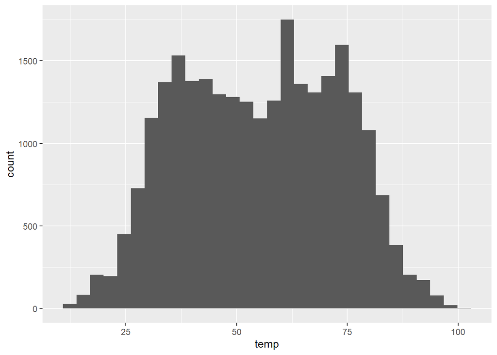

```r
weather1 <- subset(weather, weather$month ==1)

# Test
# The subset was too big to see here, so I ended up viewing it outside of R to confirm.
# There is likely a more efficient method using code, but I don't know it.
# weather1
# write.table(weather1, "C:\\Users\\hlear\\Desktop\\statsandviz\\r_language\\data\\weather1.tab", row.names=FALSE)


# c) Using ggplot2, make a beautiful histogram of the variable ‘temp’
library(tidyverse)
ggplot(data = weather, aes(x = temp)) + geom_histogram() # Not beautiful...
```

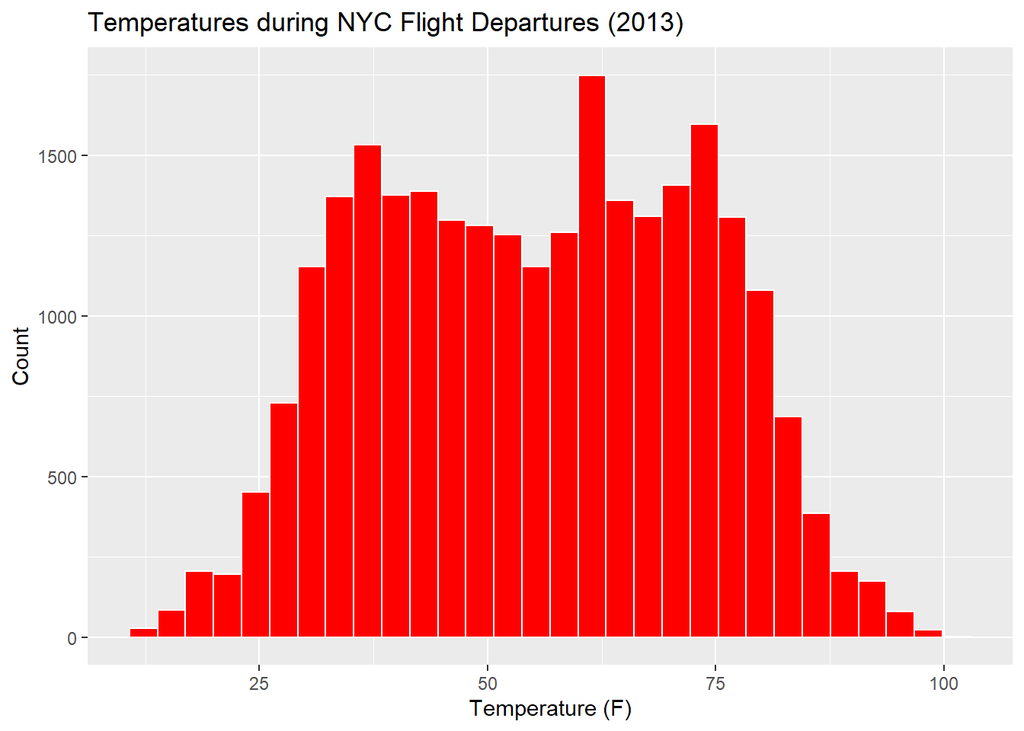

```r
# Make pretty
ggplot(data = weather, aes(x = temp)) + geom_histogram(col = "white",
                                                       fill = "red") +
  labs(title = "Temperatures during NYC Flight Departures (2013)",
       x = "Temperature (F)",
       y = "Count")
```

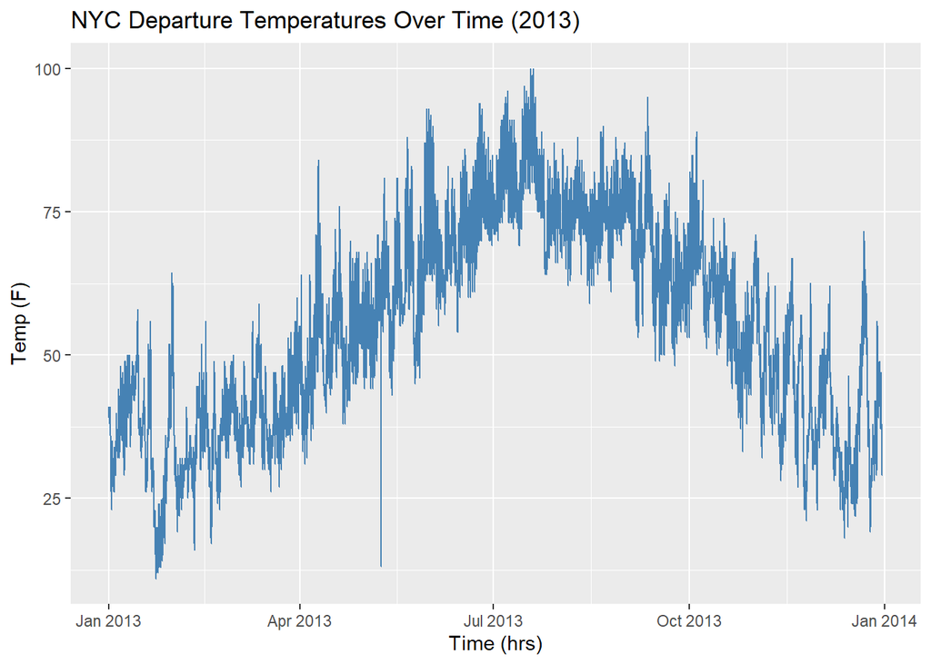

```r
# d) Using ggplot2, make a beautiful line plot of ‘temp’ as a function of ‘time_hour’
ggplot(weather, aes(x = time_hour, y = temp)) + geom_line(color = "steelblue") +
  labs(title = "NYC Departure Temperatures Over Time (2013)",
       x = "Time (hrs)",
       y = "Temp (F)")
```

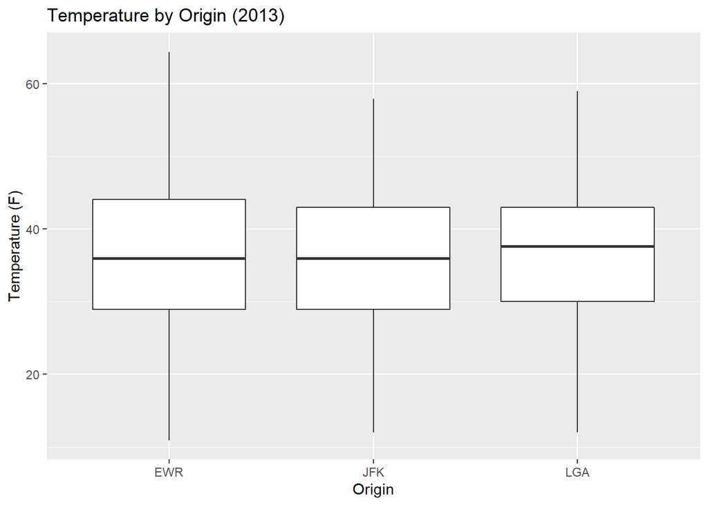

```r
# e) Using ggplot2, make a beautiful boxplot of ‘temp’ as a function of ‘origin’
ggplot(weather1, aes(x = origin, y = temp)) +
  geom_boxplot() +
  labs(title = "Temperature by Origin (2013)",
       x = "Origin",
       y = "Temperature (F)")
```